# Practical Machine Learning Course Assignment

Jill A Brown

May 21, 2017

## The Problem

Using devices such as Jawbone Up, Nike FuelBand, and Fitbit it is now possible to collect a large amount of data about personal activity relatively inexpensively. One thing that people regularly do is quantify how much of a particular activity they do, but they rarely quantify how well they do it. The participants included in the data set were asked to perform barbell lifts correctly and incorrectly in 5 different ways and the goal was to predict the manner in which they did the exercise using data from accelerometers on the belt, forearm, arm, and dumbbell of 6 participants.

## Read Data

First, we need to read in the data and clean it. There are a number of columns with undefined variables and these will be removed.

```
## [1] 19622    60
```

After the data are read in, we need to create a training and testing set. Though there’s a test set for the final part of the assignment, we still want to be able to get an out of sample error rate. The current training set is 70% of the provided training set; the test set is 30%.

```r
set.seed(1026)
train = createDataPartition(y=activitydata2$classe, p=0.7, list=FALSE)
trainact = activitydata2[train,]
testact = activitydata2[-train,]
trainact2 <- trainact[c(8:60)]
testact2 <- testact[c(8:60)]
dim(trainact2); dim(testact2)
```

```
## [1] 13737    53
```

```
## [1] 5885   53
```

```r
attach(trainact2)
```

## Explore Data

We want to look at the variables and the general structure of the data.

```
## 'data.frame':    13737 obs. of  53 variables:
##  $ roll_belt           : num  1.41 1.41 1.48 1.45 1.42 1.42 1.43 1.45 1.43 1.42 ...
##  $ pitch_belt          : num  8.07 8.07 8.05 8.06 8.09 8.13 8.16 8.18 8.18 8.2 ...
##  $ yaw_belt            : num  -94.4 -94.4 -94.4 -94.4 -94.4 -94.4 -94.4 -94.4 -94.4 -94.4 ...
##  $ total_accel_belt    : int  3 3 3 3 3 3 3 3 3 3 ...
##  $ gyros_belt_x        : num  0 0.02 0.02 0.02 0.02 0.02 0.02 0.03 0.02 0.02 ...
##  $ gyros_belt_y        : num  0 0 0 0 0 0 0 0 0 0 ...
##  $ gyros_belt_z        : num  -0.02 -0.02 -0.03 -0.02 -0.02 -0.02 -0.02 -0.02 -0.02 0 ...
##  $ accel_belt_x        : int  -21 -22 -22 -21 -22 -22 -20 -21 -22 -22 ...
##  $ accel_belt_y        : int  4 4 3 4 3 4 2 2 2 4 ...
##  $ accel_belt_z        : int  22 22 21 21 21 21 24 23 23 21 ...
##  $ magnet_belt_x       : int  -3 -7 -6 0 -4 -2 1 -5 -2 -3 ...
##  $ magnet_belt_y       : int  599 608 604 603 599 603 602 596 602 606 ...
##  $ magnet_belt_z       : int  -313 -311 -310 -312 -311 -313 -312 -317 -319 -309 ...
##  $ roll_arm            : num  -128 -128 -128 -128 -128 -128 -128 -128 -128 -128 ...
```

[output cut: 39 more lines]

```
##   roll_belt pitch_belt yaw_belt total_accel_belt gyros_belt_x gyros_belt_y
## 1      1.41       8.07    -94.4                3         0.00            0
## 2      1.41       8.07    -94.4                3         0.02            0
## 4      1.48       8.05    -94.4                3         0.02            0
## 6      1.45       8.06    -94.4                3         0.02            0
## 7      1.42       8.09    -94.4                3         0.02            0
## 8      1.42       8.13    -94.4                3         0.02            0
##   gyros_belt_z accel_belt_x accel_belt_y accel_belt_z magnet_belt_x
## 1        -0.02          -21            4           22            -3
## 2        -0.02          -22            4           22            -7
## 4        -0.03          -22            3           21            -6
## 6        -0.02          -21            4           21             0
## 7        -0.02          -22            3           21            -4
## 8        -0.02          -22            4           21            -2
##   magnet_belt_y magnet_belt_z roll_arm pitch_arm yaw_arm total_accel_arm
```

[output cut: 69 more lines]

## Build Model

Two models will be built to try to predict the class of exercise that is being performed. The models being tested are the partition and a random forest.

```
## n= 13737
##
## node), split, n, loss, yval, (yprob)
##       * denotes terminal node
##
##  1) root 13737 9831 A (0.28 0.19 0.17 0.16 0.18)
##    2) roll_belt< 130.5 12594 8694 A (0.31 0.21 0.19 0.18 0.11)
##      4) pitch_forearm< -33.95 1065    7 A (0.99 0.0066 0 0 0) *
##      5) pitch_forearm>=-33.95 11529 8687 A (0.25 0.23 0.21 0.2 0.12)
##       10) roll_forearm< 124.5 7339 4779 A (0.35 0.24 0.16 0.19 0.068)
##         20) magnet_dumbbell_y< 439.5 6072 3565 A (0.41 0.18 0.18 0.16 0.057) *
##         21) magnet_dumbbell_y>=439.5 1267  631 B (0.042 0.5 0.029 0.31 0.12) *
##       11) roll_forearm>=124.5 4190 2942 C (0.067 0.22 0.3 0.21 0.21) *
##    3) roll_belt>=130.5 1143    6 E (0.0052 0 0 0 0.99) *
```

[figure not shown]

```
##
## Call:
##  randomForest(x = x, y = y, mtry = param$mtry)
##                Type of random forest: classification
##                      Number of trees: 500
## No. of variables tried at each split: 2
##
##         OOB estimate of  error rate: 0.73%
## Confusion matrix:
##      A    B    C    D    E  class.error
## A 3904    1    1    0    0 0.0005120328
## B   17 2633    8    0    0 0.0094055681
## C    0   19 2375    2    0 0.0087646077
## D    0    0   41 2210    1 0.0186500888
## E    0    0    3    7 2515 0.0039603960
```

## Cross Validation and Out of Sample Error

In order to cross validate we try both our models on the test set that was set aside at the beginning of this exploration. First we will analyze the partition model.

```r
predictrpart <- predict(modelact, newdata=testact2, type="raw")
matrixrpart <- confusionMatrix(predictrpart, testact2$classe)
matrixrpart
```

```
## Confusion Matrix and Statistics
##
##           Reference
## Prediction    A    B    C    D    E
##          A 1519  475  482  461  175
##          B   27  318   16  154   56
##          C  120  346  528  349  357
##          D    0    0    0    0    0
##          E    8    0    0    0  494
##
## Overall Statistics
##
##                Accuracy : 0.4858
##                  95% CI : (0.473, 0.4987)
##     No Information Rate : 0.2845
##     P-Value [Acc > NIR] : < 2.2e-16
##
##                   Kappa : 0.3276
##  Mcnemar's Test P-Value : NA
##
## Statistics by Class:
##
##                      Class: A Class: B Class: C Class: D Class: E
## Sensitivity            0.9074  0.27919  0.51462   0.0000  0.45656
## Specificity            0.6217  0.94669  0.75880   1.0000  0.99833
## Pos Pred Value         0.4881  0.55692  0.31059      NaN  0.98406
## Neg Pred Value         0.9441  0.84550  0.88100   0.8362  0.89077
## Prevalence             0.2845  0.19354  0.17434   0.1638  0.18386
## Detection Rate         0.2581  0.05404  0.08972   0.0000  0.08394
## Detection Prevalence   0.5288  0.09703  0.28887   0.0000  0.08530
## Balanced Accuracy      0.7646  0.61294  0.63671   0.5000  0.72745
```

This model demonstrates a low degree of accuracy.

Now we will analyze the random forest model.

```r
predictrt <- predict(modelact2, newdata=testact2, type="raw")
matrixrt <- confusionMatrix(predictrt, testact2$classe)
matrixrt
```

```
## Confusion Matrix and Statistics
##
##           Reference
## Prediction    A    B    C    D    E
##          A 1672    5    0    0    0
##          B    0 1131   12    0    0
##          C    2    3 1014   21    0
##          D    0    0    0  943    4
##          E    0    0    0    0 1078
##
## Overall Statistics
##
##                Accuracy : 0.992
##                  95% CI : (0.9894, 0.9941)
##     No Information Rate : 0.2845
##     P-Value [Acc > NIR] : < 2.2e-16
##
##                   Kappa : 0.9899
##  Mcnemar's Test P-Value : NA
##
## Statistics by Class:
##
##                      Class: A Class: B Class: C Class: D Class: E
## Sensitivity            0.9988   0.9930   0.9883   0.9782   0.9963
## Specificity            0.9988   0.9975   0.9946   0.9992   1.0000
## Pos Pred Value         0.9970   0.9895   0.9750   0.9958   1.0000
## Neg Pred Value         0.9995   0.9983   0.9975   0.9957   0.9992
## Prevalence             0.2845   0.1935   0.1743   0.1638   0.1839
## Detection Rate         0.2841   0.1922   0.1723   0.1602   0.1832
## Detection Prevalence   0.2850   0.1942   0.1767   0.1609   0.1832
## Balanced Accuracy      0.9988   0.9952   0.9915   0.9887   0.9982
```

This model demonstrates a high degree of accuracy. Based on these cross validation activities and the out of sample error (accuracy value), it is recommended that a random forest model be used.

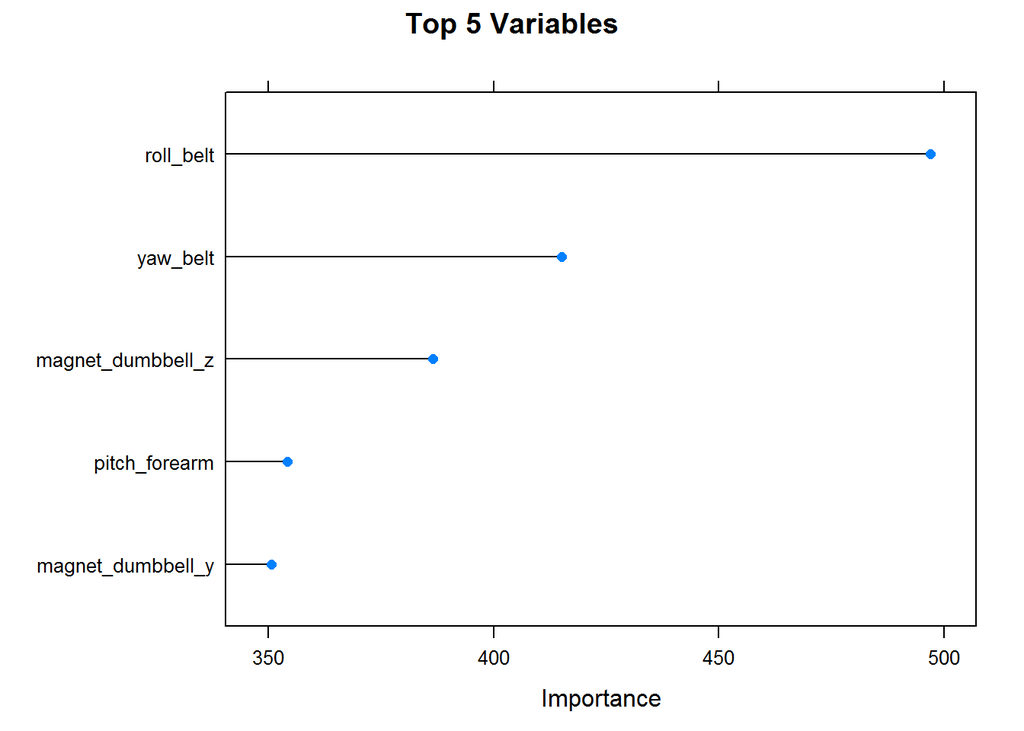

The above plot shows the most important variables by rank in the random forest prediction model.

## Final Test Data

Now the random forest model will be used to predict the final twenty values.

```r
activitydatatest <- read.csv("C:/Users/jilla/Google Drive/datasciencecoursera/machinelearning/pml-testing.csv", header=TRUE, na.strings=c('','NA','#DIV/0!'))
activitydatatest2 <- activitydatatest[ , colSums(is.na(activitydatatest)) == 0]
predictfinal <- predict(modelact2, newdata=activitydatatest2, type="raw")
predictfinal
```

```
##  [1] B A B A A E D B A A B C B A E E A B B B
## Levels: A B C D E
```

## Citation

This dataset and corresponding information can be found here:

Ugulino, W.; Cardador, D.; Vega, K.; Velloso, E.; Milidiu, R.; Fuks, H. Wearable Computing: Accelerometers’ Data Classification of Body Postures and Movements. Proceedings of 21st Brazilian Symposium on Artificial Intelligence. Advances in Artificial Intelligence - SBIA 2012. In: Lecture Notes in Computer Science. , pp. 52-61. Curitiba, PR: Springer Berlin / Heidelberg, 2012. ISBN 978-3-642-34458-9. DOI: 10.1007/978-3-642-34459-6_6.

Read more: http://groupware.les.inf.puc-rio.br/har#ixzz4hikb2jJM